# Producing basic graphs in R: A cheat sheet

Clayton Visger

Examples below are just ONE way to make these graphs. ggplot is very flexible and often there are many ways to make the same graph

1. Load ggplot2

```r
library(ggplot2)
```

2. Read in your data

```
data <- read.csv(“location/data.csv”)
```

3. Check that your data read in correctly

```
head(data)
```

4. First ggplot line Write the first part of ggplot that includes information on the dataset and which variables will be x and y This line will pretty much always be the same, regardless of what type of graph you want to make note: fill is optional

```
ggplot(data, aes(x=name_of_independent_variable, y=name_of_dependent_variable, fill=name_of_variable_to_color_by))
```

Now you just add lines of code below your ggplot line to customize your graph note: you need to add a ‘+’ sign at the end of each line if you plan to add another line below e.g.:

```
ggplot(data, aes(x=name_of_independent_variable, y=name_of_dependent_variable, fill=name_of_variable_to_color_by)) +
    stat_summary(geom = "bar", fun.y = mean)
```

5. ggplot modifier lines
- lines to add that determine the type of graph
  - Bar graph

    ```
    stat_summary(geom = "bar", fun.y = mean)
    ```

  - Scatterplot (shape and color are optional)

    ```
      stat_summary(geom="point", aes(color=name_of_variable_to_color_by, shape=name_of_variable_to_shape_by))
    ```

- adding error bars (stdev) to a bar graph (alter width and color to taste)

  ```
  stat_summary(geom = "errorbar", fun.data = mean_sdl, width = 0.2, color = "black")
  ```

- adding individual labels

  ```
  xlab("Sepal Length")
  ylab("Sepal Width")
  ggtitle("Sepal Length vs Width")
  ```

- adding multiple labels in a single line

  ```
  labs(x = "cylinders", y="mpg", fill="number of cylinders")
  ```

- adding a linear regression line

  ```
  stat_smooth(method = "lm", col = "red")
  ```

- adding the equation for a linear regression line

  ```
  geom_text(label = "y = 3.932x - 17.58, R-squared = 0.65", x = 7, y = 80, col = "red")
  ```

6. Histograms
- Simple histogram

  ```
  hist(mtcars$mpg)
  ```

- Colored histogram with different number of bins (breaks)

  ```
  hist(mtcars$mpg, breaks=12, col="red")
  ```

- histogram in ggplot example

  ```
  ggplot(data=mtcars, aes(x=mpg)) +
  geom_histogram(binwidth=5, color="black", aes(fill=as.factor(am))) +
    xlab("mpg") +  ylab("Frequency") + ggtitle("Histogram of mpg by transmisison")
  ```

7. Example graphs and code from the graphing in R video

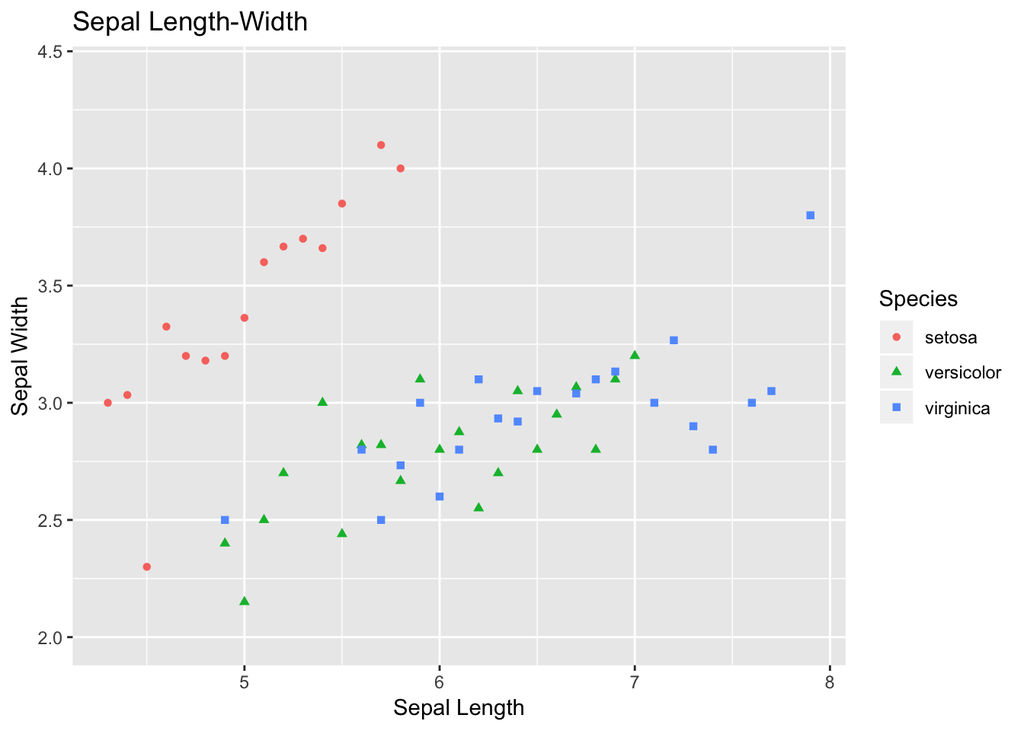

```r
ggplot(data=iris, aes(x = Sepal.Length, y = Sepal.Width)) +
  stat_summary(geom="point", aes(color=Species, shape=Species)) +
  xlab("Sepal Length") +  ylab("Sepal Width") +
  ggtitle("Sepal Length-Width")
```

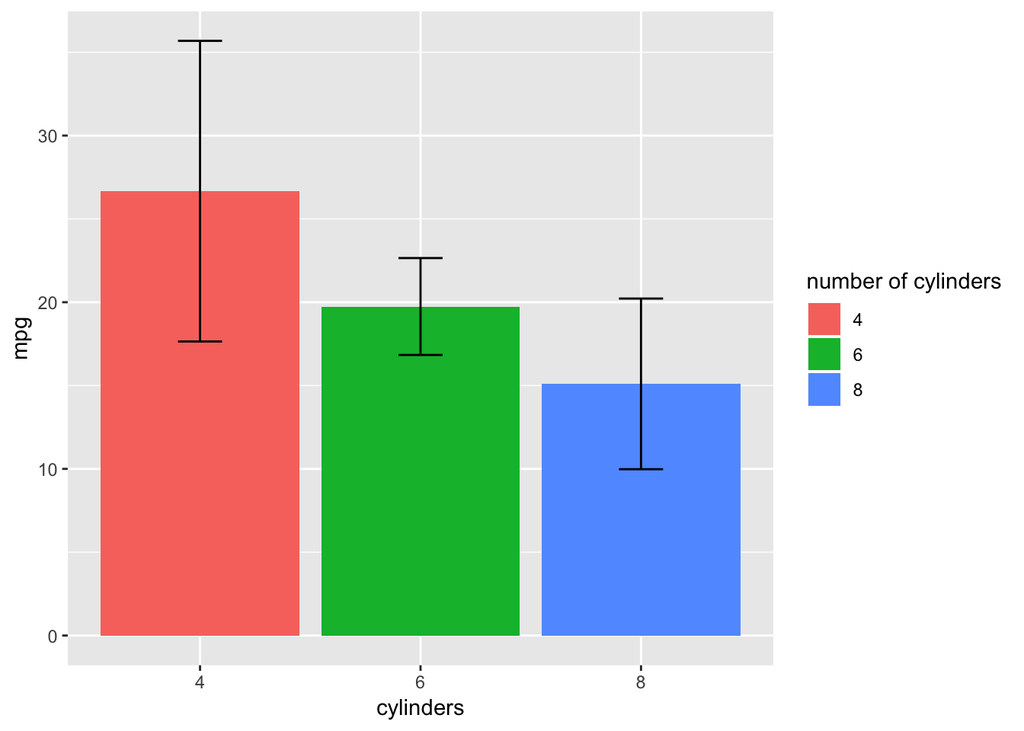

```r
ggplot(mtcars, aes(x=as.factor(cyl), fill=as.factor(cyl), y=mpg)) +
    stat_summary(geom = "bar", fun.y = mean) +
    stat_summary(geom = "errorbar", fun.data = mean_sdl, width = 0.2, color = "black") +
    labs(x = "cylinders", y="mpg", fill="number of cylinders")
```

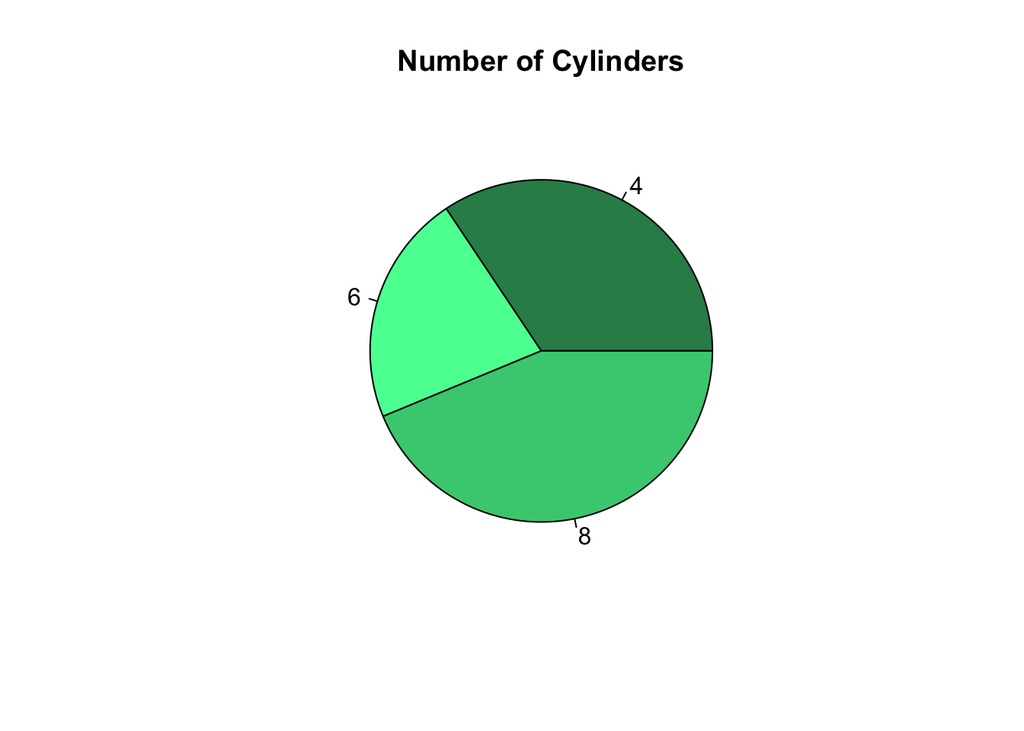

```r
pie(table(mtcars$cyl), col=c("seagreen", "seagreen1", "seagreen3"), main="Number of Cylinders")
```

### Want to learn more?

If you are hungry for more ideas visit http://r-statistics.co/ggplot2-cheatsheet.html note: the authors of this page prefer to save each line as a variable rather than keeping the graph as one big block of code e.g.,

```
graph <- ggplot(data, aes(x=name_of_independent_variable, y=name_of_dependent_variable, fill=name_of_variable_to_color_by)) +

graph + stat_summary(geom = "bar", fun.y = mean)
```

vs

```
ggplot(data, aes(x=name_of_independent_variable, y=name_of_dependent_variable, fill=name_of_variable_to_color_by)) +
    stat_summary(geom = "bar", fun.y = mean)
```

Neither is wrong, it is just a matter of personal preference